# 热工基础 · 第 3 讲：气体混合物、水蒸汽、湿空气与气体流动

刘训臣

山东科技大学 机械电子工程学院

# 第〇部分 · 课程介绍与本讲定位

- 教学内容与主线、7 次课进度表（第 3 行加粗）
- 本讲定位：平衡判据用到化学反应与相变，再进入可压缩流动
- 气体混合物与化学平衡（JANAF）、水蒸气与湿空气
- 一维流动、拉瓦尔喷管、激波与节流壅塞

## 第 3 讲：教学内容与主线

> **两个课时、两条主线：组分可变的平衡 → 速度可变的流动。**

**课时 1 · 气体混合物、化学平衡与水蒸气**

- 气体混合物：成分表示、折合气体常数、Dalton 分压定律
- 化学反应平衡：JANAF 表 → 平衡常数 $K_f$ → van’t Hoff → 绝热火焰温度
- 水蒸气：相图、Clausius–Clapeyron、水蒸气表与图（T-s、Mollier）

**课时 2 · 湿空气与气体流动**

- 湿空气参数与焓湿图（h-d 图）
- 一维可压缩流动：声速、马赫数、驻点与临界参数
- 拉瓦尔喷管、正激波、小孔节流与壅塞

> 一句话：**课时 1 把平衡判据用到组分可变（化学反应）与相变（水蒸气）；课时 2 把能量方程用到可压缩流动（喷管）。**

## 教学进度 · 7 次课全览

| 次 | 教材章 | 主题 | 课时 1 / 课时 2 |
| --- | --- | --- | --- |
| 1 | 第 1、2 章 | 基本概念、统计热力学与热力学基本定律 | 基本概念与统计力学图像 / 热力学基本定律与函数 |
| 2 | 第 3 章 | 理想气体与热力过程 | 理想气体（状态方程、内能、熵） / 热力过程与 Carnot 循环 |
| **3** | **第 4、5 章** | **气体混合、水蒸汽、湿空气与气体流动** | **气体混合物、水蒸汽与湿空气 / 气体流动与喷管** |
| 4 | 第 6、7 章 | 压气机与动力循环、制冷循环 | 压气机与气体动力循环 / 蒸汽动力循环与制冷循环 |
| 5 | 第 8、9 章 | 导热 | 三种传热方式与 Fourier 导热定律 / 稳态导热与热阻分析 |
| 6 | 第 10 章 | 对流换热 | 对流机理与边界层、准则数 / 准则关联式及其应用 |
| 7 | 第 11、12 章 | 热辐射、换热器与总复习 | 热辐射基本定律与辐射换热计算 / 换热器与全课程总复习 |

## 本讲在课程中的位置

- **第 1 讲**：$S(U,V,N)$ 公理框架、强度量与平衡判据（$\mu_1=\mu_2$ 等）
- **第 2 讲**：理想气体配分函数与过程计算（$pV^n$ 一族、Carnot 循环）
- **本讲**：把平衡判据推广到**组分可变**（化学反应、相变），再进入**开口系可压缩流动**
- **第 4 次课**：动力循环与制冷（Rankine、Brayton、制冷循环）

**本讲要用到的旧工具**：化学势 $\mu=\mu^\circ+RT\ln(p/p^\circ)$（第 2 讲）、绝热关系 $p/\rho^\gamma=C$（第 2 讲）、能量方程（第 2 讲开口系）。

**推导留给 AI**：① 问他”化学平衡与相平衡的共同点是什么”（提示：都是化学势相等 $\mu^\alpha=\mu^\beta$、$\sum c_i\mu_i=0$）；② 让他举例说明”等温时熵最大与 $G$ 最小等价，不等温时不等价”。

# 第一部分 · 气体混合物与化学平衡

- 混合物成分表示、折合分子量与折合气体常数
- Dalton 分压定律与分容定律
- 化学反应：约束条件与优化目标
- JANAF 表、生成焓、平衡常数 $K_f$、van’t Hoff、绝热火焰温度

## 理想气体混合物的成分表示

**两种成分表示**（$n$ 为总摩尔数、$m$ 为总质量）：

$$x_i=\frac{n_i}{n}\ (\text{摩尔分数}),\qquad g_i=\frac{m_i}{m}\ (\text{质量分数}),\qquad \sum_i x_i=\sum_i g_i=1$$

- 摩尔分数与质量分数的换算：$x_i=\dfrac{g_i/M_i}{\sum_j g_j/M_j}$
- 两者都归一（和等于 1），且 $\sum_i x_iM_i=\dfrac{1}{\sum_i g_i/M_i}$

**推导留给 AI**：① 让他由 $n_i=m_i/M_i$ 推出换算式；② 问他”分压用摩尔分数、气体常数用质量分数，为什么各自最方便”（提示：$p_i=x_ip$ 与 $R_g=R/M$ 的形式）。

## 混合物的折合分子量与算例

**折合分子量与折合气体常数**（混合物的”平均”）：

$$M_{eq}=\frac{m}{n}=\sum_i x_i M_i=\frac{1}{\sum_i g_i/M_i},\qquad
R_{g,eq}=\frac{R}{M_{eq}}=\sum_i g_i R_{g,i}$$

**算例（空气，双组分近似 $g_{N_2}=0.768$、$g_{O_2}=0.232$）**：

$$M_{eq}=\frac{1}{0.768/28.016+0.232/32.0}=28.85\ \text{g/mol},\qquad R_{g,eq}=\frac{8314}{28.85}=288\ \text{J/(kg·K)}$$

- 与手册空气值（$M=28.966$、$R_g=287$ J/(kg·K)）的差异来自忽略的稀有气体
- 摩尔分数（空气）：$x_{N_2}=0.791$、$x_{O_2}=0.209$

**推导留给 AI**：① 让他验证 $M_{eq}=\sum x_iM_i$ 与 $M_{eq}=1/\sum(g_i/M_i)$ 等价；② 让他补上 Ar（$g_{Ar}=0.0129$、$M=39.95$）重算 $M_{eq}$，看是否落到 28.96。

## Dalton 分压定律与分容定律

**Dalton 分压定律**：混合气体总压 = 各组分**分压**之和，分压 = 组分独占总体积时的压力：

$$p=\sum_i p_i,\qquad p_i=x_i\,p\quad(\text{分压按摩尔分数分配})$$

**Amagat 分容定律**：总体积 = 各组分**分容**之和（组分在同温同总压下占有的体积）：

$$V=\sum_i V_i,\qquad V_i=x_i\,V$$

> 两条定律都来自理想气体状态方程的**线性性**（$p_i=n_iRT/V$），是一件事的两个写法。

## 分压定律的应用：湿空气与燃烧产物

**两个直接应用**：

- **湿空气**：$p=p_a+p_v$（干空气分压 + 水蒸气分压）——湿度计算的起点
- **燃烧产物**：各组分分压由摩尔分数给出，代入化学平衡判据（本部分后半）

**工作实例（湿空气）**：总压 101.325 kPa、水蒸气分压 $p_v=2.544$ kPa 时

- 摩尔分数 $x_v=p_v/p=0.0251$（水蒸气占 2.5%）
- 干空气分压 $p_a=98.78$ kPa——含湿量 $d=0.622\,p_v/p_a$ 的由来（第三部分再讲）

**推导留给 AI**：① 让他用 $p_i=x_ip$ 核对上面两组数；② 问：“分压定律与分容定律是否相互独立？”（提示：都来自理想气体状态方程的线性性。）

## 化学反应的微观图景

- 在一定约束条件下，**原子核重组**（原子核数守恒）、化学键重排
- 驱动力是**熵最大**
- 表现形式：各组分摩尔数 $N_i$ 变化，使目标热力学函数最小化
- 过程中伴随吸热/放热，温度 $T$ 也可能同时变化

## 约束条件与优化目标

| 约束 | 优化目标 | 现实装置 | 测量输出 |
| --- | --- | --- | --- |
| TP | $G$ 最小 | 化工反应器 | 平衡组成、反应速率 |
| HP | $S$ 最大 | 燃气轮机燃烧室 | 绝热火焰温度、污染物 |
| SP | $H$ 最小 | 理想透平 | 输出功、出口温度 |
| UV | $S$ 最大 | 弹式量热计 | 燃烧热、最高温度压力 |
| TV | $F$ 最小 | 高压实验釜 | 压力变化、相平衡 |
| SV | $U$ 最小 | 理论模型 | 压力温度关系 |

## JANAF 数据库

**查表方法**（以水蒸气为例，参考零点 $T_r = 298.15$ K）：

1. 第 1 列：温度 $T$ [K]
2. 第 2–4 列：热容 $C_p^\circ=\partial H/\partial T$、熵 $S=\int_0^T C_p/T\,dT$、Gibbs 自由能 $G^\circ=H^\circ-TS$（同一分子内自洽）
3. 第 5 列：焓 $H^\circ$ [kJ/mol]，以 $T_r$ 为零点
4. 第 6、7 列：生成焓 $\Delta_f H^\circ$、生成 Gibbs 自由能 $\Delta_f G^\circ=\mu^\circ$（不同分子间统一标尺）

## 图：JANAF 表（水蒸气）

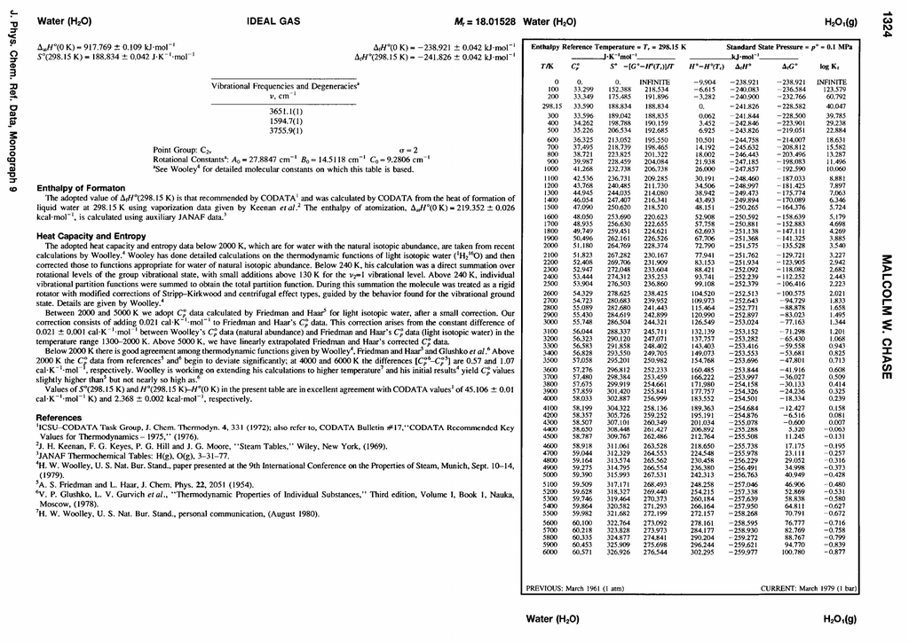

JANAF table of water(gas)

## 图：JANAF 表分析（1）

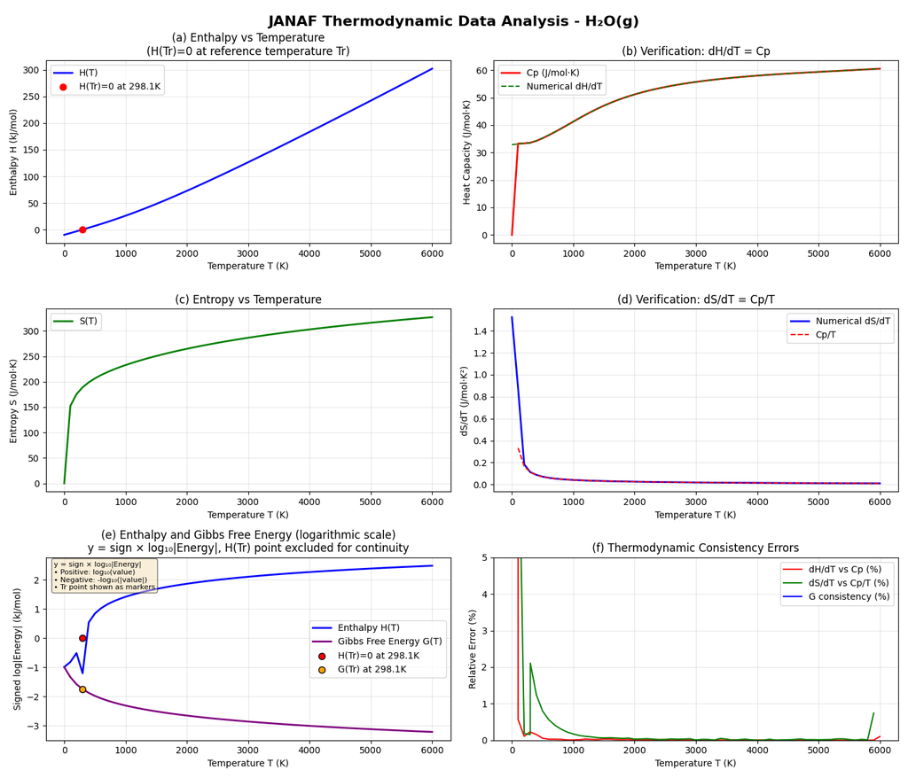

JANAF table of water(gas), analysis

## 图：JANAF 表分析（2）

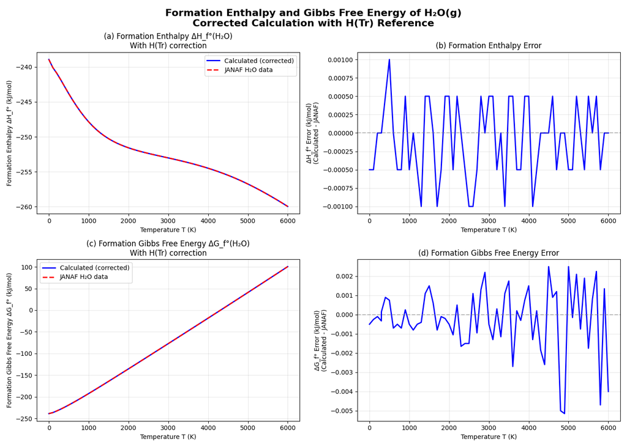

JANAF table of water(gas), analysis

## 生成焓

不同分子之间的能量差由参考温度 $T_r$ 处的生成焓 $\Delta_fH^\circ$ 体现；单质生成焓取零：

$$\Delta_fH^\circ(\text{H}_2\text{O},T) = [H_{\text{H}_2\text{O}}(T)-H_{\text{H}_2\text{O}}(T_r)] - [H_{\text{H}_2}(T)-H_{\text{H}_2}(T_r)] - 0.5[H_{\text{O}_2}(T)-H_{\text{O}_2}(T_r)] + \Delta_fH^\circ(\text{H}_2\text{O},T_r)$$

## 生成 Gibbs 自由能与平衡常数

分子的标准化学势（生成 Gibbs 自由能）写成无量纲数：

$$-\frac{\mu^\circ}{RT} = \ln K_f$$

- JANAF 每行的 $\Delta_fG^\circ$（$=\mu^\circ$）与 $K_f$ 对应特定温度、压力下的反应自由能与平衡常数
- 任意反应的总平衡常数：$K = \prod_i (K_f)^{c_i}$

## 反应 Gibbs 自由能

各组分分压为 $p_i$ 时：

$$\Delta G_r = \sum_i c_i\mu_i^\circ + RT\ln\left[\prod_i\left(\frac{p_i}{p^\circ}\right)^{c_i}\right] = RT\ln\frac{Q}{K}$$

其中

$$Q = \prod_i\left(\frac{p_i}{p^\circ}\right)^{c_i},\qquad K = \prod_i (K_f)^{c_i}$$

## 平衡条件

- $Q$：当前压力商；$K$：平衡常数
- 平衡时 $Q_{eq} = K$
- $\Delta G_r = RT\ln(Q/K)$：
  - $Q < K$：$\Delta G_r < 0$，正向（生成物方向）自发进行
  - $Q > K$：$\Delta G_r > 0$，逆向（反应物方向）自发进行
  - $Q = K$：$\Delta G_r = 0$，化学平衡

## van’t Hoff 关系

温度对平衡常数的影响：

$$\frac{\partial \ln K_f}{\partial (1/T)} = -\frac{\Delta_f H^\circ}{R}$$

- 放热反应（$\Delta_f H^\circ < 0$）：升温使平衡常数下降
- 吸热反应（$\Delta_f H^\circ > 0$）：升温使平衡常数上升

## 图：JANAF 平衡常数（van’t Hoff）

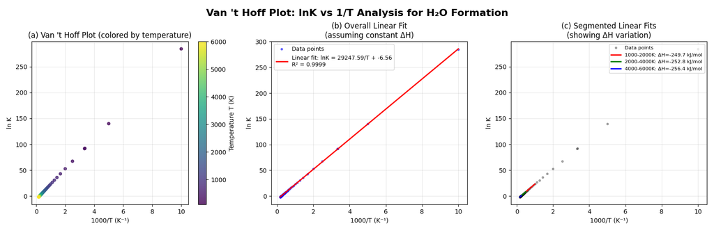

JANAF table of water(gas), analysis

## HP 约束：绝热火焰温度（思路 1）

**扫描配比**：

1. 在元素守恒约束下改变组分配比
2. 对每个配比，在 HP 约束下求温度
3. 计算熵，找熵最大的配比

## HP 约束：绝热火焰温度（思路 2）

**迭代温度**：

- 把温度 $T$ 也作为变量
- 在元素守恒与 HP 约束下，采用平衡系数（$K_f$）迭代求解温度

## 图：H₂/O₂ 反应进度

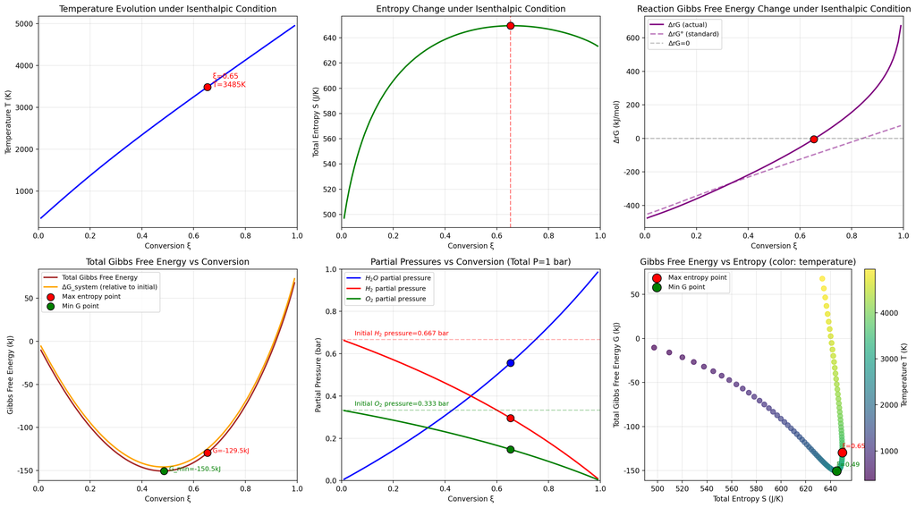

Reaction progress of H2 and O2

## 课时 1 小结

- 化学平衡 = 约束条件下的热力学函数最小化（TP→$G$、HP→$S$、SP→$H$、UV→$S$、TV→$F$）
- JANAF 提供 $H^\circ$、$S$、$G^\circ$、$\Delta_fH^\circ$、$\Delta_fG^\circ$、$K_f$
- TP 约束 → $\Delta G_r = RT\ln(Q/K)$；平衡时 $Q = K$
- 温度影响 → van’t Hoff：$\partial \ln K_f/\partial(1/T) = -\Delta_f H^\circ/R$
- HP 约束 → 绝热火焰温度（焓守恒 + 熵最大 / 平衡系数迭代）

# 第二部分 · 水蒸气

- 水的相图：三相点与临界点
- Clausius–Clapeyron 关系与饱和蒸气压
- 水蒸气表、IAPWS-IF97、T-s 图与 Mollier 图
- 定压汽化过程：一点、两线、三区、五态

## 水的相图

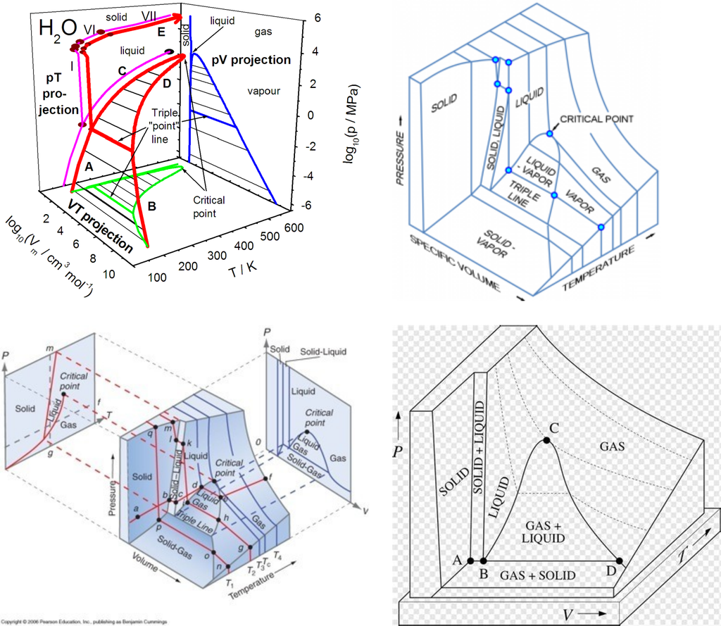

在 p-T 图中，相平衡线把固、液、气三相分开：

- 饱和蒸气压 $p_e$ 随温度上升
- 相平衡线上两相共存；线外是单相区
- 两个关键点：**三相点**（三相共存）与**临界点**（气液不再可分）

## 图：水的相图

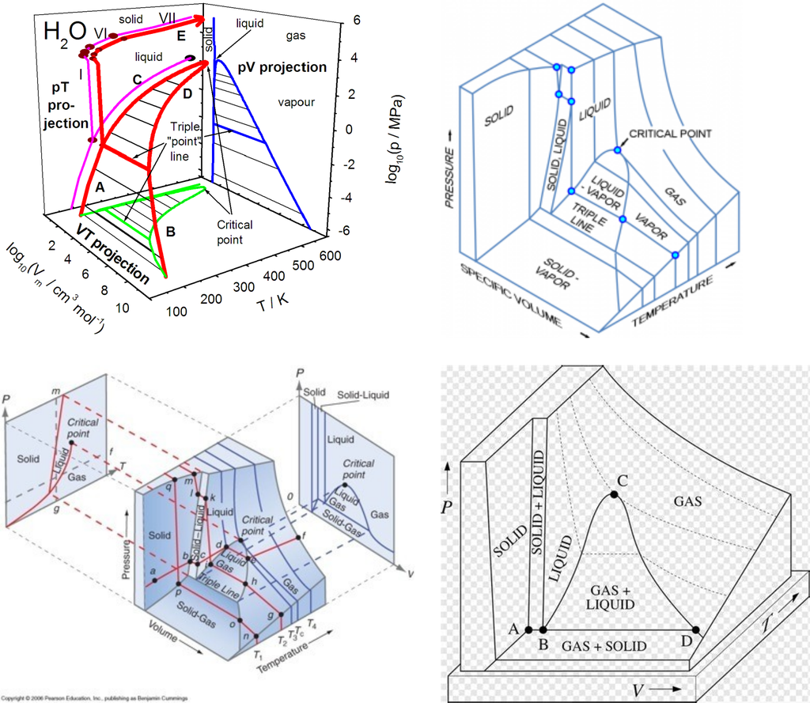

phase diagram of water

## 三相点与临界点

- **三相点**：固、液、气三相共存的唯一状态
  - $T_{tp} = 273.16\,\text{K}$（0.01 ℃），$p_{tp} = 611.657\,\text{Pa}$
- **临界点**：汽化线的终点
  - $T_c = 647.096\,\text{K}$（373.946 ℃），$p_c = 22.064\,\text{MPa}$

## Clausius-Clapeyron 关系

相平衡时（由 Maxwell 关系 $(\partial S/\partial V)_T = (\partial p/\partial T)_V$ 出发）：

$$\left(\frac{dp}{dT}\right)_e = \frac{\Delta H_e}{T_e\,\Delta V} = \frac{\Delta h_e}{T_e}\,\frac{p_e}{k_B T_e}$$

$$d\ln p_e = -\frac{\Delta h_e}{k_B}\,d\left(\frac{1}{T_e}\right)$$

## 饱和蒸气压公式

积分 Clausius-Clapeyron（假设 $\Delta h_e$ 近似常数）：

$$\ln p_e = A - \frac{\Delta h_e}{k_B T_e}$$

- 饱和蒸气压随温度近似**指数变化**
- 温度越高，$p_e$ 上升越快

## 水蒸气表与 IAPWS-IF97

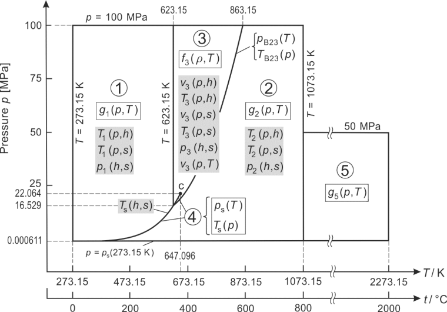

IAPWS-IF97 区域划分

- 水蒸气性质由 IAPWS-IF97 工业标准计算（https://www.iapws.org）
- 用 $T$、$p$ 等两个独立参数即可查得 $v, h, s$ 等全部热物性
- 常用图表：不同压力下的 **T-s 图**、T-v / P-v 图、**Mollier 图（h-s 图）**

## 图：IAPWS-IF97

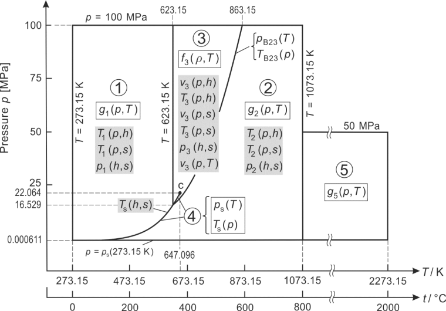

the iapws-IF97 database

## 图：水的 T-s 图

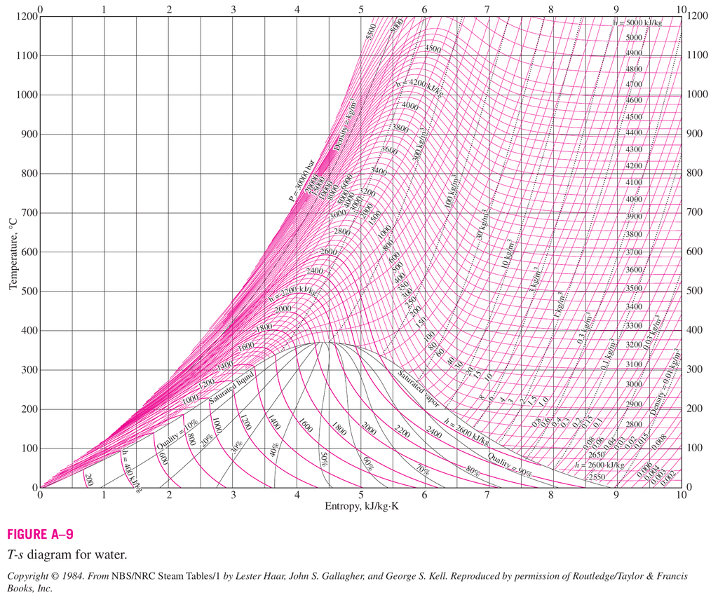

水的温度熵图

## 图：水 T-v / P-v 图

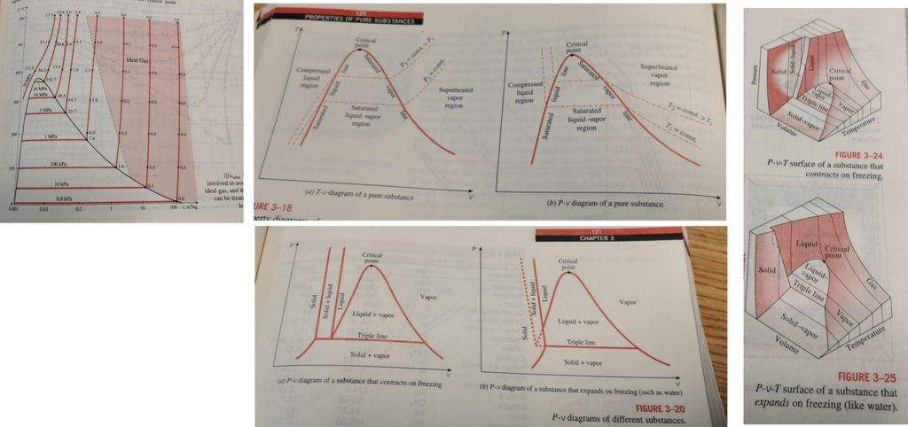

水 T-v / P-v 图

## 图：Mollier 图

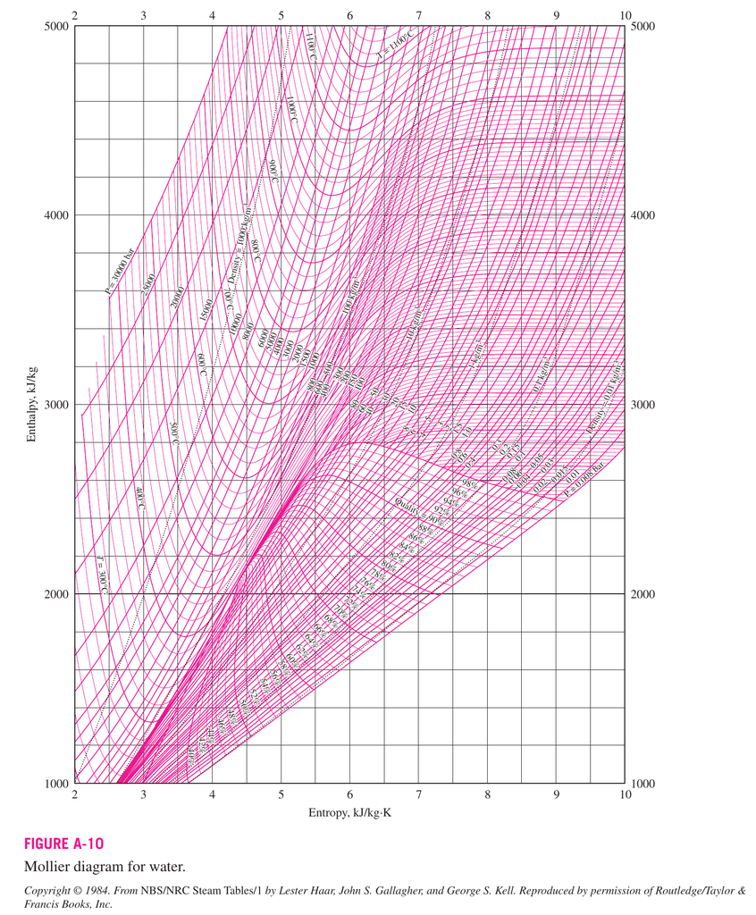

Mollier diagram of water

## 水蒸气定压汽化过程

定压加热液体：未饱和水 → 饱和水 → 湿蒸汽 → 干饱和蒸汽 → 过热蒸汽

- 湿蒸汽阶段（两相区）：温度**恒定**为饱和温度，$T$、$p$ 不再独立
- 干度 $x = \dfrac{m_{\text{汽}}}{m_{\text{汽}} + m_{\text{液}}}$；湿蒸汽 $0 < x < 1$
- 继续加热到干饱和蒸汽后，再升温进入过热阶段

# 第三部分 · 湿空气

- 绝对湿度、相对湿度、含湿量、露点
- 含湿量与焓的计算公式
- 焓湿图（h-d 图）的线族
- 加热、冷却去湿、绝热加湿等典型过程

## 湿空气：基本参数

- **绝对湿度** $\rho_v$：单位体积湿空气中所含水蒸气的质量，$\rho_v = \dfrac{p_v}{R_v T}$
- **相对湿度** $\varphi = \dfrac{p_v}{p_s}$：水蒸气分压与同温度饱和蒸气压之比
- **含湿量** $d = \dfrac{m_v}{m_a}$：单位质量干空气所含的水蒸气质量
- **露点** $t_d$：定压冷却到水蒸气开始凝结的温度（$p_v = p_s(t_d)$ 时 $\varphi=1$）

## 湿空气参数与计算

- 含湿量（$0.622 = M_v/M_a$）：

$$d = 0.622\,\frac{p_v}{p - p_v} = 0.622\,\frac{\varphi\, p_s}{p - \varphi\, p_s}\quad[\text{kg/kg 干空气}]$$

- 湿空气焓（以 1 kg 干空气为基准，$t$ 单位 ℃）：

$$h = 1.005\,t + d\,(2501 + 1.86\,t)\quad[\text{kJ/kg 干空气}]$$

## 焓湿图（h-d 图）

- 湿空气状态变化与空调、干燥过程计算的基本工具
- 主要线族：等焓线、等含湿量线、等温线、等相对湿度线
- 给定任意两个独立参数，即可在图上定点读其余参数

## 焓湿图上的典型过程

| 过程 | 特征 | 参数变化 |
| --- | --- | --- |
| 加热（等湿） | $d$ 不变，$t$ 升 | $\varphi$ 下降，$h$ 升高 |
| 冷却（到露点前） | $d$ 不变，$t$ 降 | $\varphi$ 升高，$h$ 下降 |
| 冷却去湿 | 降到 $\varphi=100\%$ 后再降 | $d$ 减小（析出凝结水） |
| 绝热加湿（喷水） | 近似沿等焓线 | $d$ 升、$t$ 降、$\varphi$ 升 |

- 相平衡与 Clausius-Clapeyron：饱和蒸气压指数依赖温度
- 三相点、临界点是相图的两个关键点
- 工程计算：IAPWS-IF97 / T-s 图 / Mollier（h-s）图
- 湿空气：$\varphi = p_v/p_s$、$d = 0.622\dfrac{p_v}{p-p_v}$、$h = 1.005t + d(2501+1.86t)$
- 焓湿图上的加热、冷却、去湿、加湿过程

# 第四部分 · 一维流动与声速

- 一维欧拉方程与伯努利积分（动能+焓守恒）
- 声速 $a=\sqrt{\gamma RT}$、马赫数与可压缩性判据
- 驻点参数、临界参数与等熵标量关系
- 扰动传播与马赫锥

## 知识点 1 · 一维可压缩流动基本方程

## 理想流体基本方程组（Euler 方程）

忽略黏性、传热（绝热）、重力，理想气体、定比热的欧拉方程组：

$$\frac{\partial\rho}{\partial t} + \nabla\cdot(\rho \vec{u}) = 0$$

$$\frac{\partial(\rho \vec{u})}{\partial t} + \nabla\cdot(\rho \vec{u}\otimes\vec{u}) = -\nabla p$$

$$\frac{d}{dt}\left(\frac{p}{\rho^\gamma}\right) = 0$$

## 一维流动的控制方程

只沿 $x$ 方向流动时，方程简化为：

$$\frac{\partial\rho}{\partial t} + u\frac{\partial\rho}{\partial x} + \rho\frac{\partial u}{\partial x} = 0$$

$$\frac{\partial u}{\partial t} + u\frac{\partial u}{\partial x} + \frac{1}{\rho}\frac{\partial p}{\partial x} = 0$$

$$\frac{d}{dt}\left(\frac{p}{\rho^\gamma}\right) = 0$$

## 伯努利积分：动能 + 焓守恒

定常流动时能量守恒给出伯努利积分——动能与焓之和沿流线不变：

$$\frac{u^2}{2} + \frac{\gamma}{\gamma-1}\frac{p}{\rho} = \frac{u^2}{2} + \frac{a^2}{\gamma-1} = \frac{u^2}{2} + h = \frac{u^2}{2} + c_pT = C_3$$

## 知识点 2 · 声速、马赫数与可压缩性

## 小扰动传播与声速

在静止气体中引入小扰动 $p=p_0+p'$，$\rho=\rho_0+\rho'$，$u=u'$，线性化后得到波动方程：

$$\frac{\partial^2 u'}{\partial t^2} = a^2\frac{\partial^2 u'}{\partial x^2}, \qquad u' = f(x-at) + g(x+at)$$

声速即小扰动的传播速度：

$$p' = a^2\rho', \qquad a = \sqrt{\left(\frac{\partial p}{\partial\rho}\right)_S} = \sqrt{\gamma\frac{p}{\rho}} = \sqrt{\gamma RT}$$

## 马赫数

马赫数 = 流速与声速之比：

$$Ma = \frac{u}{a}$$

它反映动能与内能的相对大小：

$$\frac{\text{动能}}{\text{内能}} \sim \frac{u^2}{c_pT} \sim (\gamma-1)Ma^2$$

## 可压缩性判据

密度相对变化量由马赫数决定：

$$\frac{\rho'}{\rho} \sim -\frac{1}{2}Ma^2$$

- $Ma \ll 1$：可忽略压缩性（近似不可压缩流）
- $Ma \gg 1$：压缩性显著

## 知识点 3 · 驻点参数、临界参数与等熵关系

## 驻点参数

动能全部转化为内能后的参考量（速度被“驻”为零）：

$$\frac{u^2}{2} + c_pT = c_pT_0$$

$$\frac{\gamma}{\gamma-1}\frac{p_0}{\rho_0} = \frac{a_0^2}{\gamma-1} = h_0 = c_pT_0 = C_3$$

## 临界参数

当流速恰好等于当地声速 $u_*=a_*$ 时，得到临界参考量 $p_*,\rho_*,T_*$：

$$\frac{u^2}{2} + \frac{a^2}{\gamma-1} = \frac{u_\text{max}^2}{2} = \frac{a_0^2}{\gamma-1}$$

$$\frac{\gamma+1}{2(\gamma-1)}a_*^2 = C_3$$

## 等熵标量关系

绝热（等熵）条件下各热力学量与马赫数的关系：

$$\frac{p}{p_0} = \left(1+\frac{\gamma-1}{2}Ma^2\right)^{-\frac{\gamma}{\gamma-1}}, \qquad \frac{T}{T_0} = \left(1+\frac{\gamma-1}{2}Ma^2\right)^{-1}$$

$$\frac{\rho}{\rho_0} = \left(1+\frac{\gamma-1}{2}Ma^2\right)^{-\frac{1}{\gamma-1}}, \qquad \frac{a}{a_0} = \left(1+\frac{\gamma-1}{2}Ma^2\right)^{-\frac12}$$

## 等熵标量关系：微分链（讲义）

**讲义 eq:scalar-relation 的完整链条**——绝热条件下各标量按同一规律变化：

$$\frac{dp}{p}=\gamma\frac{d\rho}{\rho}
=\frac{\gamma}{\gamma-1}\frac{dT}{T}
=\frac{\gamma}{\gamma-1}\frac{dh}{h}
=\frac{2\gamma}{\gamma-1}\frac{da}{a}$$

$$\frac{p}{p_0}=\left(\frac{\rho}{\rho_0}\right)^\gamma
=\left(\frac{T}{T_0}\right)^{\frac{\gamma}{\gamma-1}}
=\left(\frac{h}{h_0}\right)^{\frac{\gamma}{\gamma-1}}
=\left(\frac{a}{a_0}\right)^{\frac{2\gamma}{\gamma-1}}
=\left(1+\frac{\gamma-1}{2}Ma^2\right)^{-\frac{\gamma}{\gamma-1}}$$

- 标量变化规律相同，且**按顺序变小**（$p$ 降得最快、$a$ 降得最慢）
- **速度决定了标量与驻点参考量的比值**——给定任一位置的速度，即可得到任意两位置的标量比：
  $$\frac{p_1}{p_2}=\left(\frac{1+\frac{\gamma-1}{2}Ma_1^2}{1+\frac{\gamma-1}{2}Ma_2^2}\right)^{-\frac{\gamma}{\gamma-1}}$$

## 任意两位置的参数比

给定任意两个位置的速度（马赫数），即可由驻点参数消去得到两者标量比：

$$\frac{p_1}{p_2} = \frac{p_1/p_0}{p_2/p_0} = \left(\frac{1+\frac{\gamma-1}{2}Ma_1^2}{1+\frac{\gamma-1}{2}Ma_2^2}\right)^{-\frac{\gamma}{\gamma-1}}$$

## 知识点 4 · 扰动传播与马赫锥

## 扰动传播与马赫锥

扰动源以速度 $u$ 运动，扰动波前的包络面构成**马赫锥**，马赫角：

$$\sin\alpha = \frac{a}{u} = \frac{1}{Ma}$$

- $Ma<1$：扰动能传到上游各处
- $Ma>1$：扰动无法逆流上传，锥外形成**寂静区**

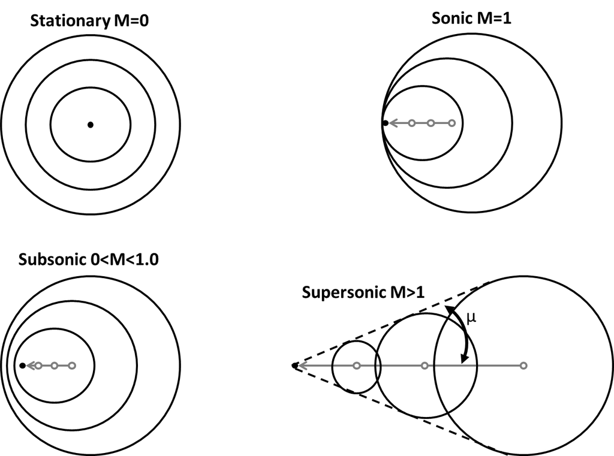

声速的传播与马赫角

# 第五部分 · 喷管与节流

- 面积-速度关系与拉瓦尔喷管（三种工况）
- 正激波与激波管
- 小孔节流、壅塞与流量反算总温总焓
- Rayleigh 流（加热/冷却的影响）

## 知识点 5 · 准一维定常流动与拉瓦尔喷管

## 面积-速度关系

定常准一维流（$A$ 随 $x$ 变化），由质量与动量方程：

$$\frac{dA}{A} = (Ma^2-1)\frac{du}{u}, \qquad \frac{du}{u} = -\frac{1}{Ma^2-1}\frac{dA}{A}$$

## 亚声速与超声速的行为

|  | 收缩（$dA<0$） | 扩张（$dA>0$） |
| --- | --- | --- |
| 亚声速 $Ma<1$ | 加速 | 减速 |
| 超声速 $Ma>1$ | 减速 | 加速 |

## 面积比与马赫数（$A/A^*$）

喉部（最小截面）达到声速 $Ma=1$ 时的面积为临界面积 $A^*$：

$$\frac{A}{A^*} = \frac{1}{Ma}\left[\frac{2+(\gamma-1)Ma^2}{\gamma+1}\right]^{\frac{\gamma+1}{2(\gamma-1)}}$$

## 拉瓦尔喷管

收扩（收敛-扩张）喷管：收缩段加速到喉部 $Ma=1$，扩张段继续加速到超声速。

- 收缩段：亚声速加速
- 喉部：$Ma=1$（临界状态）
- 扩张段：超声速加速

## 拉瓦尔喷管的三种工况

1. **等熵亚声速**：出口背压高，全管亚声速
2. **等熵超声速**：出口背压低，全管超声速
3. **管内激波**：背压介于两者之间，扩张段出现正激波

## 知识点 6 · 正激波与激波管

## 正激波：三大守恒

激波是强间断，波前(1)后(2)满足质量、动量、能量守恒（Rankine-Hugoniot）：

$$\rho_1u_1 = \rho_2u_2, \qquad p_1+\rho_1u_1^2 = p_2+\rho_2u_2^2$$

$$h_1 + \frac{u_1^2}{2} = h_2 + \frac{u_2^2}{2}$$

## 正激波前后关系

对完全气体，由守恒方程解得：

$$\frac{p_2}{p_1} = 1 + \frac{2\gamma}{\gamma+1}(Ma_1^2-1), \qquad \frac{\rho_2}{\rho_1} = \frac{(\gamma+1)Ma_1^2}{2+(\gamma-1)Ma_1^2}$$

普朗特关系（速度乘积不变）：

$$u_1u_2 = a_*^2$$

## 激波管

- 高压区(4)与低压区(1)之间用薄膜隔开
- 薄膜破裂后产生**激波**（向低压区）与**膨胀波**（向高压区）
- 用于研究激波、爆轰与超声速流动

**激波管方程**（lec_31.tex，下标 1=低压区、4=高压区）：

$$\frac{p_4}{p_1}=\frac{2\gamma_1 Ma_1^2-(\gamma_1-1)}{\gamma_1+1}
\left[1-\frac{\gamma_4-1}{\gamma_4+1}\frac{a_1}{a_4}\left(Ma_1-\frac{1}{Ma_1}\right)\right]^{-\frac{2\gamma_4}{\gamma_4-1}}$$

- 给定压比 $p_4/p_1$（与温度比）即可反解入射激波马赫数 $Ma_1$
- 破膜瞬间接触面两侧压力、速度连续；激波加热压缩低压气体

**推导留给 AI**：① 让他说明”为什么激波管能同时产生激波与膨胀波”（提示：破膜瞬间两侧的压力不连续分解为两个波）；② 问：$p_4/p_1\to\infty$ 时 $Ma_1$ 的极限是多少？

## 知识点 7 · 小孔节流与壅塞

## 小孔节流的流量

小孔内部保持驻点参数 $p_0,T_0,\rho_0$，出口流量完全由压力比控制：

$$\dot m = \rho_0 a_0 A_1\sqrt{\frac{2}{\gamma-1}\left[\left(\frac{p_1}{p_0}\right)^{-\frac{\gamma-1}{\gamma}}-1\right]\left(\frac{p_1}{p_0}\right)^{\frac{\gamma+1}{\gamma}}}$$

## 壅塞（choked）

出口压力降到**临界压力比**以下时，出口达到声速、流量不再增加：

$$\left(\frac{p_*}{p_0}\right) = \left(\frac{2}{\gamma+1}\right)^{\frac{\gamma}{\gamma-1}} \approx 0.5283\ (\text{空气},\gamma=1.4)$$

$$\dot m_\text{max} = A\,p_0\sqrt{\frac{\gamma}{RT_0}}\left(\frac{\gamma+1}{2}\right)^{-\frac{\gamma+1}{2(\gamma-1)}}$$

## 小孔节流：由流量反算总温总焓

**最大流量（临界）的另一种写法**（讲义，用总焓 $H_0=c_pT_0$）：

$$\dot m_{max}=A_* p_0\cdot\frac{\gamma}{\sqrt{(\gamma-1)H_0}}\cdot\left(\frac{2}{\gamma+1}\right)^{\frac{\gamma+1}{2(\gamma-1)}}$$

**反解总温、总焓**（由实测 $\dot m$、$p_0$、$A_*$ 计算）：

$$T_0=\frac{A_*^2 p_0^2}{\dot m^2}\cdot\frac{\gamma}{R}\left(\frac{2}{\gamma+1}\right)^{\frac{\gamma+1}{\gamma-1}},\qquad
H_0=\frac{A_*^2 p_0^2}{\dot m^2}\cdot\frac{\gamma^2}{\gamma-1}\left(\frac{2}{\gamma+1}\right)^{\frac{\gamma+1}{\gamma-1}}$$

- 用到了 $c_p=\gamma R/(\gamma-1)$、$H_0=c_pT_0$（完全气体）——这就是**声速吼道法测量总焓**的原理（电弧风洞等高焓设备的标准测法）

**推导留给 AI**：让他从 $\dot m_{max}=A_*p_0\sqrt{\gamma/(RT_0)}((\gamma+1)/2)^{-(\gamma+1)/(2(\gamma-1))}$ 推出上两式。

## 真实气体修正与半经验公式

**真实气体的问题**：$c_p$ 随温度升高（转动、振动逐步激发，高焓时还有离解、电离），$H_0$ 与 $T_0$ 不再线性。

**通用形式**（不再用 $\gamma$ 常数，改用真实气体的两个比值）：

$$\dot m=A_* p_0\cdot\frac{\sqrt{H_0}}{RT_0}\cdot\frac{\rho_*}{\rho_0}\sqrt{2\left(1-\frac{h_*}{H_0}\right)}$$

**推导留给 AI**：让他验证完全气体时通用式退回 $\dot m_{max}$ 的 $\gamma$ 形式。

## Fanno 线与 Rayleigh 线（提及）

- **Fanno 流**：绝热、有摩擦的等截面管流（$h$-$s$ 图上为 Fanno 线）
- **Rayleigh 流**：有换热、无摩擦的等截面管流（加热/冷却改变流动）

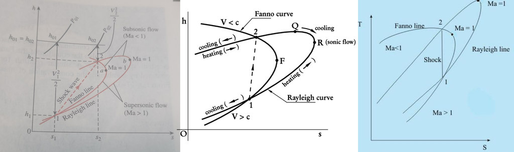

Fanno 线与 Rayleigh 线

## Rayleigh 线的 T-s 图

加热/冷却对 Rayleigh 流的影响（亚声速与超声速相反）：

- 加热：$T_0\uparrow$、$s\uparrow$；亚声速加速，超声速减速
- 冷却：$T_0\downarrow$、$s\downarrow$；亚声速减速，超声速加速

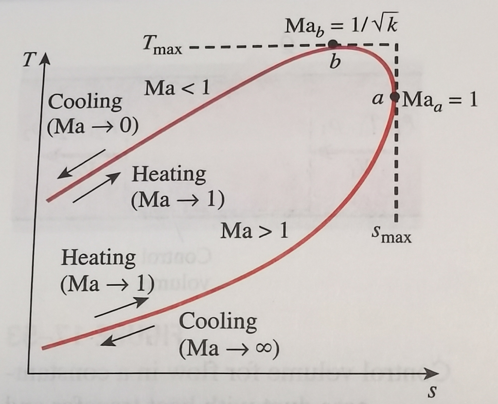

Rayleigh 线（T-s 图）

## Rayleigh 流：守恒方程与前后关系

**非绝热**（有换热）的一维定常流动：质量守恒 $\rho u=C_1$、动量守恒 $p+\rho u^2=C_2$（能量被换热改变，不再是常数）。由两式（配 $u=Ma\sqrt{\gamma RT}$）得波前(1)后(2)关系：

$$\frac{p_2}{p_1}=\frac{1+\gamma Ma_1^2}{1+\gamma Ma_2^2},\qquad
\frac{T_2}{T_1}=\left[\frac{Ma_2(1+\gamma Ma_1^2)}{Ma_1(1+\gamma Ma_2^2)}\right]^2$$

$$\frac{\rho_2}{\rho_1}=\frac{u_1}{u_2}=\frac{Ma_1^2(1+\gamma Ma_2^2)}{Ma_2^2(1+\gamma Ma_1^2)}$$

- 非绝热时标量本身会变（如加热后总温上升），但**前后两状态点的标量比由当地速度（马赫数）决定**；与等熵标量关系联立即可求解（加热量 → 总温变化 → 反解马赫数 → 各标量）

**推导留给 AI**：让他用 $p+\rho u^2=C$ 与 $u=Ma\sqrt{\gamma RT}$ 推出 $p_2/p_1$ 式。

## Rayleigh 流：临界化与两个特殊点

**统一转化到临界状态（$Ma=1$）**：

$$\frac{p}{p^*}=\frac{1+\gamma}{1+\gamma Ma^2},\qquad
\frac{T}{T^*}=\left[\frac{Ma(1+\gamma)}{1+\gamma Ma^2}\right]^2,\qquad
\frac{\rho^*}{\rho}=\frac{u}{u_*}=\frac{Ma^2(1+\gamma)}{1+\gamma Ma^2}$$

**总参数（$T_0$、$p_0$）也统一转化到临界状态**：

$$\frac{T_0}{T_0^*}=\left(1+\frac{\gamma-1}{2}Ma^2\right)\left[\frac{Ma(1+\gamma)}{1+\gamma Ma^2}\right]^2\left(1+\frac{\gamma-1}{2}\right)^{-1}$$

$$\frac{p_0}{p_0^*}=\frac{\gamma+1}{1+\gamma Ma^2}\left[\frac{2+(\gamma-1)Ma^2}{\gamma+1}\right]^{\frac{\gamma}{\gamma-1}}$$

## Rayleigh 线上的两个特殊点

**Rayleigh 线上两个特殊点**（T-s 图上）：

- **右顶点（熵最大）**：$\dfrac{ds}{dT}=0\ \Rightarrow\ Ma=1$——加热到声速即壅塞
- **上顶点（温度最高）**：$\dfrac{dT}{ds}=0\ \Rightarrow\ Ma=1/\sqrt{\gamma}$（空气 $\approx0.845$）

> 注：讲义 eq:17 给出的 $ds/dT$ 微分式第二项分母有量纲疑点（$T-u^2/R$），此处只写结论（Ma=1 熵最大、Ma=1/√γ 温度最高），该式未照抄。

**推导留给 AI**：① 让他由 $T/T^*$ 式对 $Ma$ 求导验证温度极值在 $Ma=1/\sqrt\gamma$；② 问：“为什么熵最大点（Ma=1）与温度最高点（Ma=1/√γ）不重合？”（提示：$T_0$ 与 $T$ 的关系随 $Ma$ 变化。）

## Rayleigh 加热与冷却的影响（讲义表）

**加热与冷却对 Rayleigh 流各参数的影响**（讲义表，亚声速与超声速相反）：

| 参数 | 加热·亚声速 | 加热·超声速 | 冷却·亚声速 | 冷却·超声速 |
| --- | --- | --- | --- | --- |
| $u$ | $\uparrow$ | $\downarrow$ | $\downarrow$ | $\uparrow$ |
| $Ma$ | $\uparrow$ | $\downarrow$ | $\downarrow$ | $\uparrow$ |
| $T_0$ | $\uparrow$ | $\uparrow$ | $\downarrow$ | $\downarrow$ |
| $T$ | $Ma<1/\sqrt\gamma$ 升，否则降 | $\uparrow$ | $Ma<1/\sqrt\gamma$ 降，否则升 | $\downarrow$ |
| $\rho$ | $\downarrow$ | $\uparrow$ | $\uparrow$ | $\downarrow$ |
| $p_0$ | $\downarrow$ | $\downarrow$ | $\uparrow$ | $\uparrow$ |
| $p$ | $\downarrow$ | $\uparrow$ | $\uparrow$ | $\downarrow$ |
| $s$ | $\uparrow$ | $\uparrow$ | $\downarrow$ | $\downarrow$ |

**最该记住的两条**：① 加热总使 $T_0\uparrow$、$p_0\downarrow$、$s\uparrow$；② 加热使**亚声速加速、超声速减速**（都朝 $Ma=1$ 走）。

**推导留给 AI**：① 让他解释”为什么加热在亚声速加速、超声速减速”（提示：$p+\rho u^2=C$ 与 $Ma$ 的关系）；② 让他举例：燃烧室（亚声速加热）加燃料过多会发生什么？（答：向壅塞逼近，流量受限。）

## 例题：蒸汽喷管节流算例

喷管/节流问题通常用 $h$-$s$（Mollier）图直接读焓差求功或速度。

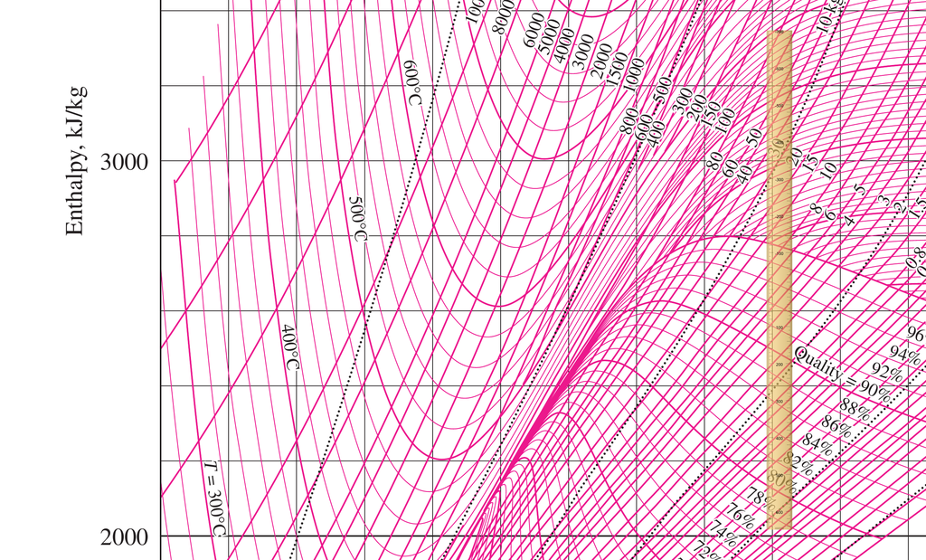

例题 4-3：喷管流动算例（h-s 图）

# 第六部分 · 例题、小结与作业

- 三道水蒸气真题
- 讲义思考题 2 道（电加热器管道、超声速风洞）
- 作业：计算题 4 道 + 思考题 3 道
- 本讲小结与下讲预告

## 课堂例题 1：湿蒸汽的温度（真题）

**判断**：水的定压汽化过程，湿蒸汽阶段的温度会有所升高。（2025—2026 学年 A 卷）

**参考答案**：错误。

- 定压汽化过程中，湿蒸汽阶段处于**饱和温度**，温度不变
- 继续加热到干饱和蒸汽后才进入过热阶段，温度才升高

## 课堂例题 2：一点、两线、三区、五态（真题）

**简答**：指出水定压气化过程 p-v 图中的“一点、两线、三区、五态”的具体含义。（2025—2026 学年 B 卷 / 2024—2025 春 B 卷）

**参考答案**：

- **一点**：临界点
- **两线**：饱和水线（下界线）、干饱和蒸汽线（上界线）
- **三区**：液态区、湿蒸汽区、过热蒸汽区
- **五态**：未饱和水、饱和水、湿饱和蒸汽、干饱和蒸汽、过热蒸汽

## 课堂例题 3：定压汽化的能量计算（真题）

**计算**：1 kg 温度为 100 ℃ 的饱和水在 $p=0.1013$ MPa 下定压加热气化变为饱和蒸汽。已知 $v_1=0.00104$ m³/kg，$v_2=1.6736$ m³/kg，加热量 $q=2256.6$ kJ/kg。求工质热力学能和焓的变化。（2025—2026 学年第二学期 A 卷）

**参考答案**：

- 定压过程热量等于焓变：$\Delta h = q = 2256.6$ kJ/kg
- 膨胀功：$w = p(v_2-v_1) = 0.1013\times10^6\times(1.6736-0.00104) \approx 169.4$ kJ/kg
- 热力学能变化：$\Delta u = q - w = 2256.6 - 169.4 = 2087.2$ kJ/kg

## 讲义思考题（lec_3 原题，2 道）

> 出处：`lec_3.tex`「思考题」段（426 行起）。答案要点经 Python 复核。

**题 1（电加热管道）**：9.5 MW 电加热器加热内径 198 mm 不锈钢圆管内的空气流。入口条件：$t_1=50$ ℃、$p_1=1$ MPa、$\dot m=20$ kg/s。求出口条件。（$\gamma=1.4$、$c_p=1.00$ kJ/(kg·K)）

**题 2（超声速风洞）**：风洞由高压气源、拉瓦尔喷管、试验段组成，试验段参数 $Ma=3$、截面积 225 cm²、$-20$ ℃、50 kPa。求入口（气源）条件、喉道速度与标量、压气机功率。

## 讲义思考题：解题要点

**题 1 要点**：

- 单位质量吸热：$q=\dot Q/\dot m=9.5\times10^6/20=475$ kJ/kg
- 能量守恒（加热即焓升）：$T_{02}\approx T_{01}+q/c_p\approx 325+475=800$ K $\approx 527$ ℃（含动能修正；忽略动能 525 ℃）
- 入口马赫数 $Ma_1\approx0.17$——亚声速加热：$Ma\uparrow$、$T_0\uparrow$、$p_0\downarrow$（Rayleigh 表）

**题 2 要点**：

- 驻点参数：$T_0=253.15\times2.8=708.8$ K（435.7 ℃）；$p_0=50\times2.8^{3.5}=1837$ kPa $\approx1.84$ MPa
- 面积比 $A/A^*=4.2346\Rightarrow A^*=53.1$ cm²；喉道 $T^*=590.7$ K、$a^*=u^*=487$ m/s、$p^*=970$ kPa
- 流量与功率：$\rho=0.688$ kg/m³、$u=957$ m/s、$\dot m=14.8$ kg/s、压气机功率 $\dot m\,c_pT_0\approx10.6$ MW

## 作业（本讲）：计算题四道

1. **气体混合物**：空气按 $g_{N_2}=0.768$、$g_{O_2}=0.232$（忽略稀有气体），求摩尔分数、折合分子量与折合气体常数，并与手册值（$M=28.966$、$R_g=287$ J/(kg·K)）比较差异来源。
2. **饱和蒸气压**：已知水 100 ℃ 的饱和蒸气压 101.325 kPa、汽化潜热 40.66 kJ/mol，用 Clausius–Clapeyron 估算 90 ℃ 的饱和蒸气压，与实测 70.1 kPa 比较。
3. **湿空气**：$t=30$ ℃、$\varphi=60\%$、总压 101.325 kPa（已知 30 ℃ 的 $p_s=4.24$ kPa），求含湿量 $d$、露点 $t_d$ 与焓 $h$。
4. **喷管**：空气（$\gamma=1.4$）驻点温度 $T_0=500$ K，求 $Ma=2$ 处的静温 $T$、压力比 $p/p_0$ 与面积比 $A/A^*$。

> 参考答案（Python 复核）：1. $x_{N_2}=0.791$、$x_{O_2}=0.209$、$M_{eq}=28.85$、$R_{g,eq}=288$ J/(kg·K)； 2. $p_s(90^\circ\text{C})\approx70.6$ kPa；3. $d=0.0160$ kg/kg、$t_d\approx21.4$ ℃、$h=71.1$ kJ/kg； 4. $T=277.8$ K、$p/p_0=0.128$、$A/A^*=1.69$。

## 作业（本讲）：思考题三道

1. Rayleigh 线上**熵最大点**（$Ma=1$）与**温度最高点**（$Ma=1/\sqrt\gamma$）为什么不重合？请用 $T_0$ 与 $T$ 的关系解释，并说明”加热管道的壅塞”发生在哪个点。
2. 为什么拉瓦尔喷管必须”先收缩后扩张”，而单纯收缩喷管最多只能加速到声速？请从 $dA/A=(Ma^2-1)du/u$ 出发论证，并说明喉部”声速”与”流量最大”为什么同时发生。
3. 露点与霜点有何区别？为什么冬天窗户上有时结霜而不是露水？结合 $\varphi=100\%$ 线与水三相点回答。

> 各页”推导留给 AI”按当次讲到的部分布置 8–10 个小问；提交要求同前两讲（自己先推 → 让 AI 校验 → 交自己的推导）。

## 本讲小结

**课时 1 · 混合物、化学平衡与水蒸气**

- 混合物：$x_i$、$g_i$、$M_{eq}$、$R_{g,eq}$、Dalton 分压、分容
- 化学平衡：约束定目标（TP→$G$、HP→$S$）；JANAF → $K_f$ → $\Delta G_r=RT\ln(Q/K)$ → van't Hoff → 绝热火焰温度
- 水蒸气：Clausius–Clapeyron、IF97、T-s/Mollier 图、定压汽化五态

**课时 2 · 湿空气与气体流动**

- 湿空气：$\varphi$、$d$、露点、焓湿图
- 一维可压缩流动：伯努利积分、声速、马赫数、驻点/临界参数、等熵标量关系、马赫锥
- 喷管与节流：$dA/A=(Ma^2-1)du/u$、拉瓦尔喷管、正激波、壅塞 0.5283

> 一句话：**本讲把第 1 讲的平衡判据推广到组分可变（化学/相变），把第 2 讲的能量方程推广到可压缩流动（喷管）。**

## 下讲预告

**第 4 次课 · 第 6、7 章：压气机与动力循环、制冷循环**

- 活塞式压气机、多级压缩与中间冷却
- 气体动力循环：内燃机（定容/定压/混合加热）、燃气轮机（Brayton）
- 蒸汽动力循环（Rankine）与再热、回热
- 制冷循环与热泵：COP 与逆 Carnot

> 带上**水蒸气表与 Mollier 图**——Rankine 循环全程都在 h-s 图上算；本讲的喷管与节流就是循环的部件。